# Notebook

## 코스피와 집값의 관계

코스피 지수가 하락하면 집값도 하락할까?

['폭삭' 내려앉은 주식시장…부동산 가격도 폭락?](http://realty.chosun.com/site/data/html_dir/2018/11/07/2018110703440.html)  
[요동치는 글로벌 경제, '코로나19'발 집값 하락 오나](https://www.mk.co.kr/news/realestate/view/2020/03/267582/)

최근 1달 사이 코스피 지수는 2100 정도에서 1700까지 약 19%정도 급락했다. 전문가들 사이에는 코로나19 여파로 전 세계의 경제 위기가 찾아올 경우 국내 집값이 과거 외환위기나 글로벌 금융위기 때처럼 크게 하락할 수 있다는 관측이 나온다. 그래서 과거 통계를 통해 주가와 집값과의 관계를 밝혀보고자 한다.

## 데이터 요약

|  | 날짜 | 서울 | 경기 | 인천 | 부산 | 대구 | 광주 | 대전 | 울산 | 세종 | 강원 | 충북 | 충남 | 전북 | 전남 | 경북 | 경남 | 제주 |
| --- | --- | --- | --- | --- | --- | --- | --- | --- | --- | --- | --- | --- | --- | --- | --- | --- | --- | --- |
| 191 | 2019-10-01 | 108.05 | 99.91 | 99.38 | 93.15 | 102.77 | 103.03 | 107.70 | 85.65 | 97.84 | 89.43 | 88.28 | 92.18 | 94.59 | 102.00 | 88.76 | 86.01 | 94.18 |
| 192 | 2019-11-01 | 108.80 | 100.25 | 99.65 | 93.15 | 102.95 | 103.07 | 109.29 | 85.95 | 97.82 | 89.20 | 87.98 | 92.13 | 94.29 | 102.01 | 88.47 | 85.84 | 93.75 |
| 193 | 2019-12-01 | 110.15 | 100.93 | 100.13 | 93.67 | 103.23 | 103.11 | 110.85 | 86.47 | 98.82 | 88.83 | 87.91 | 92.19 | 94.10 | 101.96 | 88.15 | 85.94 | 93.37 |
| 194 | 2020-01-01 | 110.64 | 101.60 | 100.34 | 93.85 | 103.69 | 103.18 | 112.62 | 86.87 | 101.01 | 88.57 | 87.92 | 92.22 | 94.09 | 102.01 | 87.87 | 85.99 | 93.11 |
| 195 | 2020-02-01 | 110.77 | 102.71 | 100.87 | 93.91 | 103.98 | 103.26 | 114.18 | 87.35 | 103.44 | 88.46 | 87.91 | 92.28 | 94.10 | 102.06 | 87.74 | 86.15 | 92.88 |

- **코스피 데이터(kospi)**  
  일자별 코스피의 고가, 저가, 종가 등의 데이터이며 이중 **종가(Close)** 를 사용했다.  
  출처 : yahoo finance

|  | Date | High | Low | Open | Close | Volume | Adj Close |
| --- | --- | --- | --- | --- | --- | --- | --- |
| 5594 | 2020-03-25 | 1707.640015 | 1645.280029 | 1668.189941 | 1704.760010 | 872800.0 | 1704.760010 |
| 5595 | 2020-03-26 | 1735.750000 | 1679.229980 | 1699.109985 | 1686.239990 | 992500.0 | 1686.239990 |
| 5596 | 2020-03-27 | 1759.050049 | 1668.209961 | 1756.069946 | 1717.729980 | 1077500.0 | 1717.729980 |
| 5597 | 2020-03-30 | 1729.630005 | 1659.949951 | 1670.339966 | 1717.119995 | 767800.0 | 1717.119995 |
| 5598 | 2020-03-31 | 1757.810059 | 1722.619995 | 1739.290039 | 1754.640015 | 1037500.0 | 1754.640015 |

#### 국내 집값 데이터와 코스피 데이터

서울과 경기도 및 6개의 광역시의 집값을 사용했으며 기준 단위가 월이기 때문에 코스피 값의 경우 해당 월의 종가의 평균을 사용했다.

| 날짜 | seoul | gyeonggi | incheon | busan | daegu | gwangju | daejeon | ulsan | kospi |
| --- | --- | --- | --- | --- | --- | --- | --- | --- | --- |
| 2019-10-31 | 108.05 | 99.91 | 99.38 | 93.15 | 102.77 | 103.03 | 107.70 | 85.65 | 2065.747611 |
| 2019-11-30 | 108.80 | 100.25 | 99.65 | 93.15 | 102.95 | 103.07 | 109.29 | 85.95 | 2128.272998 |
| 2019-12-31 | 110.15 | 100.93 | 100.13 | 93.67 | 103.23 | 103.11 | 110.85 | 86.47 | 2147.013489 |
| 2020-01-31 | 110.64 | 101.60 | 100.34 | 93.85 | 103.69 | 103.18 | 112.62 | 86.87 | 2203.442480 |
| 2020-02-29 | 110.77 | 102.71 | 100.87 | 93.91 | 103.98 | 103.26 | 114.18 | 87.35 | 2167.123486 |

### 코스피 값과 지역별 집값 지수 그래프

[interactive chart not shown]

#### 검은색 선이 코스피 지수 값(오른쪽 y축), 그 밑의 값들이 집값 지수(왼쪽 y축)

- 전체적으로 코스피지수와 집값모두 시간이 지남에 따라 증가하는 추세를 보임을 알 수 있다.
- 그래프를 통해 **서울, 인천, 경기**의 집값추이가 비슷한 형태를 보임을 알 수 있다.
- 2008년에 코스피 지수가 1년사이에 2000에서 1000가까이 떨어지며 급락했지만 이 기간동안 집값은 하락하지 않았다.  
  #### 종합적으로 코스피와 집값은 장기적으로 증가하고 있는 추세를 보이는 것을 제외하면 크게 연관성이 있어 보이지 않는다.

### 지역별 집값과 코스피의 상관계수 히트맵

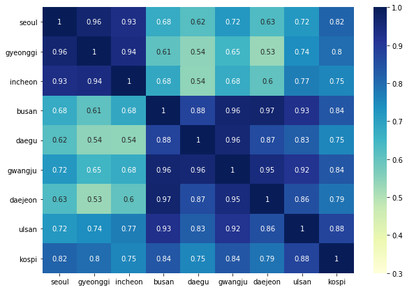

- 전체적으로 상관계수가 0.5 이상의 값을 가지며 서로 상관이 있어 보인다. 특히 (서울, 경기, 인천)과 (나머지 광역시들)의 상관계수는 전체적으로 높다.
- 코스피와 지역별 집값과의 상관계수(맨 아래 행)를 살펴보면 전부 0.75 이상의 높은 값을 기록했다.  
  #### 하지만 이는 집값과 코스피가 모두 '시간이 지남에 따라 증가하는 추세'를 가지고 있기 때문이며 이로 인해 높은 상관계수 값을 가지게 된다. 따라서 차분(differencing)을 통해 정상시계열로 변환 후 분석해야한다.

### 차분을 통해 추세를 없앤 시계열 그래프 및 상관계수 히트맵

[interactive chart not shown]

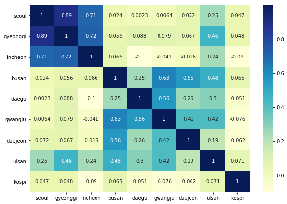

- **서울, 경기, 인천**은 차분 후에도 여전히 높은 상관계수를 가지고 있으며 집값의 추이가 유사하다고 해석할 수 있다.
- 나머지 지역의 경우 서로 어느정도 연관성이 있지만 (서울, 경기, 인천)과의 상관계수는 울산을 제외하면 매우 낮다. #### 코스피와 지역별 집값의 상관계수의 절댓값은 모두 0.1 이하로 **코스피와 집값은 밀접한 관련이 없다.** 라고 해석할 수 있다.

### 그렇다면 최근과 같이 코스피가 급락했을 때에는 집값이 어떤 추이를 보일까?

### 코스피 지수가 한달사이 15%이상 하락한 구간(red zone)

[interactive chart not shown]

총 8개의 구간에서 한달새 코스피 지수는 15%이상 하락했다. 하락하기 시작한 시점을 기준으로 3, 6, 12개월 후의 집값의 변동을 통해 코스피 급락이 집값에 미치는 영향이 유의미한지를 **bootstrap method**를 이용해 검정할 것이다.

### 코스피 급락 구간에서의 서울과 부산의 집값

총 8개의 구간이 있으므로 각각 8개의 선이 존재하고, 코스피가 급락하기 시작한 일자에서 n개월 후 집값 변동을 나타낸다.

[interactive chart not shown]

- 전체적으로 코스피가 급락해도 집값은 크게 떨어지지 않음을 알 수 있다.
- 하지만 집값은 시간이 지남에따라 증가하는 추세를 가지고 있기 때문에 임의로 8개의 구간을 택해 그래프를 나타낸다면 대부분의 선은 **우상향**하는 형태를 보일 것이다.
- 서울과 같이 8개중 6개의 선분의 증감률 값(y값)이 0보다 작다는 뜻은 코스피의 급락이 집값의 하락에 영향을 미친다고 해석할 수 있지만 표본의 수가 작으므로(8개) 가설을 명확히 지지하지는 못할 것이다.

#### Bootstrap method

임의의 8개의 날짜를 택해 그 시점으로부터 n개월 후 집값의 변동의 평균을 $X_n$이라고 하면 $X_n$은 어느정도 정규분포를 따르게 된다.(8개의 표본의 평균이므로) 그래서 표본 추출과정을 1000회 반복해 $X_n$이 따르는 정규 분포의 평균과 표준편차를 추정 후 z-test 를 통해 코스피 급락 구간에서 집값의 변동이 다른 구간과 유의미한 차이를 보이는지를 검정할 것이다.

### 지역별 z-score

|  | seoul | gyeonggi | incheon | busan | daegu | gwangju | daejeon | ulsan |
| --- | --- | --- | --- | --- | --- | --- | --- | --- |
| 3 | -1.573057 | -1.147419 | 0.494962 | -0.427701 | -1.794648 | 0.411567 | 0.401006 | -0.780193 |
| 6 | -1.265498 | -0.744995 | 0.183295 | -0.668896 | -2.051035 | -0.068909 | -0.477471 | -0.072359 |
| 12 | -0.433910 | -0.345265 | 0.622479 | -0.789741 | -2.110540 | -0.799828 | -0.490832 | 0.063496 |

(*z-score 값이 작은 경우는 코스피가 급락한 구간에서의 집값이 **평소보다 상승폭이 적거나 하락했다는 뜻** 이며 z-score 값이 음수더라도 코스피 급락 시점으로부터 n개월 후 집값이 상승한 경우도 있음. - 하락한다고 단언할 수 없는 이유는 집값은 **상승하는 추세**를 가지고 있기 때문)

[interactive chart not shown]